# ECMT674-Termproject-Team18

Jinrui Li

2025-04-30

# PART A - SIYU HE

## 1. Load Data and Initial Visualization

```r
library(tidyverse)
library(readxl)
library(forecast)
library(ggfortify)
library(ggplot2)
library(tseries)
library(tsibble)
library(zoo)

data <- read_excel("~/Documents/课程文件/3. 674-Economic Forecasting/Term Project/Texas Tax Revenue.xlsx", sheet = "Sales Tax")
saletax_ts <- ts(data$'Sales Tax', frequency = 12, start = c(2003, 9))
```

### Trend Plot

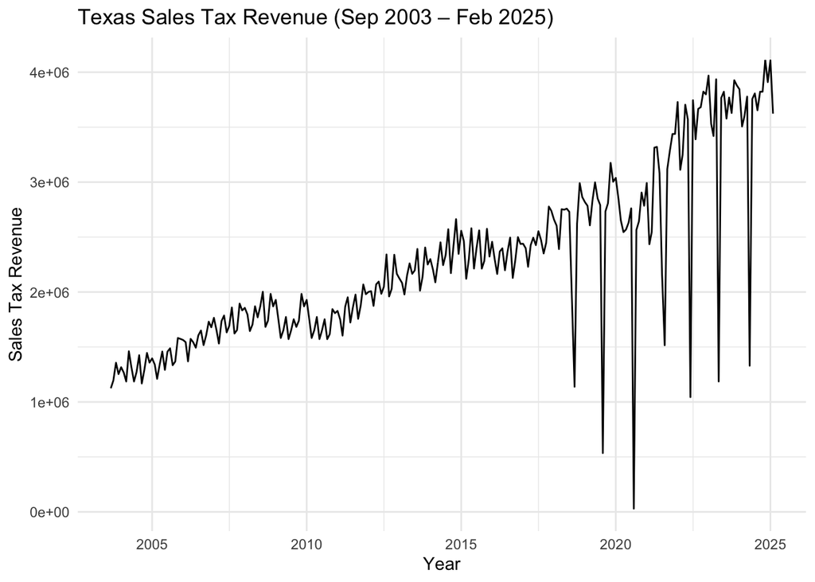

```r
autoplot(saletax_ts) +
  ggtitle("Texas Sales Tax Revenue (Sep 2003 – Feb 2025)") +
  xlab("Year") +
  ylab("Sales Tax Revenue") +
  theme_minimal()
```

#Note: The data has an upward trend.

### Seasonal Plot

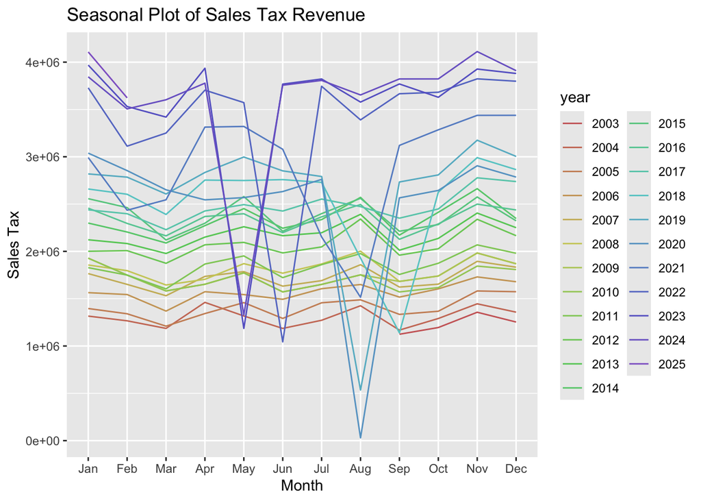

```r
ggseasonplot(saletax_ts, year.labels = FALSE, main = "Seasonal Plot of Sales Tax Revenue",
             col = rainbow(30, s = 0.5, v = 0.8), ylab = "Sales Tax")
```

#Note: The data has seasonal trends.

## 2. Log Transformation

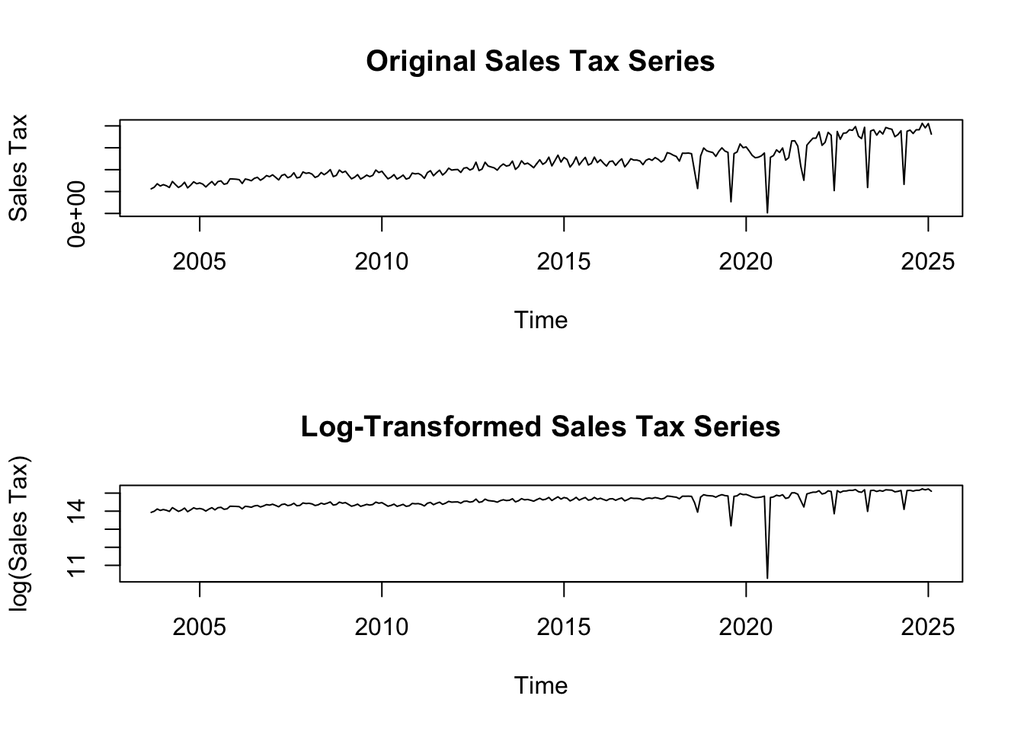

```r
log_saletax_ts <- log(saletax_ts)

par(mfrow = c(2, 1))
plot(saletax_ts, main = "Original Sales Tax Series", ylab = "Sales Tax")
plot(log_saletax_ts, main = "Log-Transformed Sales Tax Series", ylab = "log(Sales Tax)")
```

### Analysis: The original data exhibits large fluctuations in the later period (high variance), while the log-transformed series shows a more stable pattern (reduced variance).

## 3. Data Cleaning (Before Modeling)

```r
tax.dat <- read_excel("~/Documents/课程文件/3. 674-Economic Forecasting/Term Project/Texas Tax Revenue.xlsx", sheet = "Sales Tax")
sales <- ts(tax.dat[, "Sales Tax"], frequency = 12, start = c(2003, 9))

xdat <- ts(matrix(0, nrow = 258, ncol = 7), frequency = 12, start = c(2003, 9))
xdat[181,1] <- 1; xdat[192,2] <- 1; xdat[204,3] <- 1; xdat[216,4] <- 1; xdat[226,5] <- 1; xdat[237,6] <- 1; xdat[249,7] <- 1

(tr_fit <- tslm(sales ~ trend + xdat, lambda=0))
```

```
##
## Call:
## tslm(formula = sales ~ trend + xdat, lambda = 0)
##
## Coefficients:
##  (Intercept)         trend  xdatSeries 1  xdatSeries 2  xdatSeries 3
##    14.081197      0.004123     -0.882466     -1.682987     -4.639842
## xdatSeries 4  xdatSeries 5  xdatSeries 6  xdatSeries 7
##    -0.740528     -1.154617     -1.072156     -1.007503
```

```r
holiday <- xdat[,1]*tr_fit$coefficients[3] + xdat[,2]*tr_fit$coefficients[4] +
  xdat[,3]*tr_fit$coefficients[5] + xdat[,4]*tr_fit$coefficients[6] +
  xdat[,5]*tr_fit$coefficients[7] + xdat[,6]*tr_fit$coefficients[8] +
  xdat[,7]*tr_fit$coefficients[9]

sales_adj <- exp(log(sales) - holiday)
```

## 4. Log Transformation (Before Modeling)

```r
log_sales_adj <- log(sales_adj)
dates <- seq(as.Date("2003-09-01"), by = "month", length.out = length(log_sales_adj))
sales_df <- data.frame(Date = dates, Log_Sales_Tax = as.numeric(log_sales_adj))
write.csv(sales_df, "log_sales_tax.csv", row.names = FALSE)
```

# PART B - JOY SCHUMANN

## 1. Training and test sets

```r
train <- window(log_sales_adj, end = c(2024, 8))
test <- window(log_sales_adj, start = c(2024, 9))
```

## 2. Fit ETS/ARIMA model on training data

```r
ets_fit <- ets(train)
arima_fit <- auto.arima(train, seasonal = TRUE, stepwise = FALSE)
```

## 3. Check residuals for ETS/ARIMA

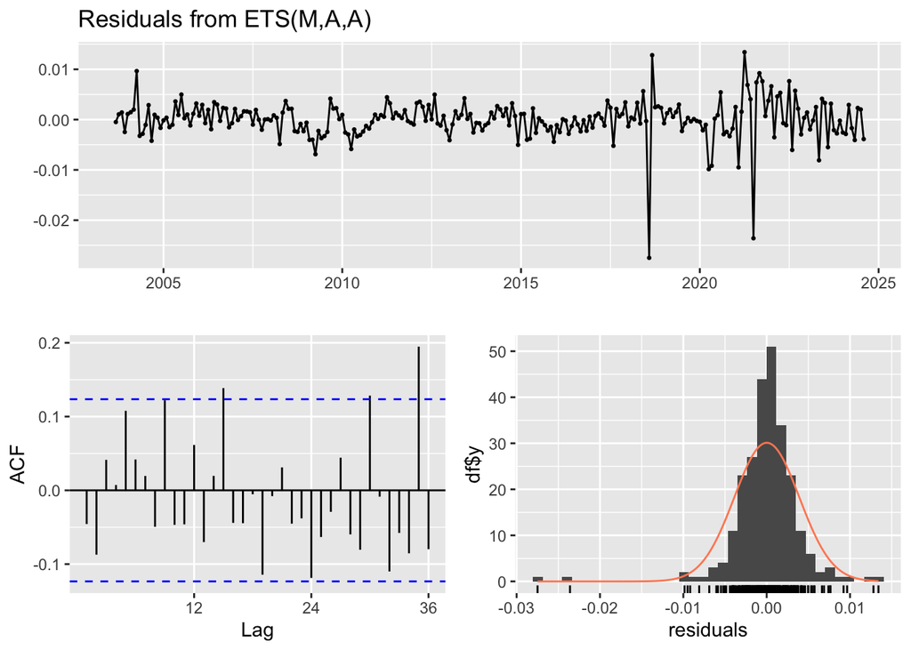

```
##
##  Ljung-Box test
##
## data:  Residuals from ETS(M,A,A)
## Q* = 29.707, df = 24, p-value = 0.1946
##
## Model df: 0.   Total lags used: 24
```

```r
checkresiduals(ets_fit)
```

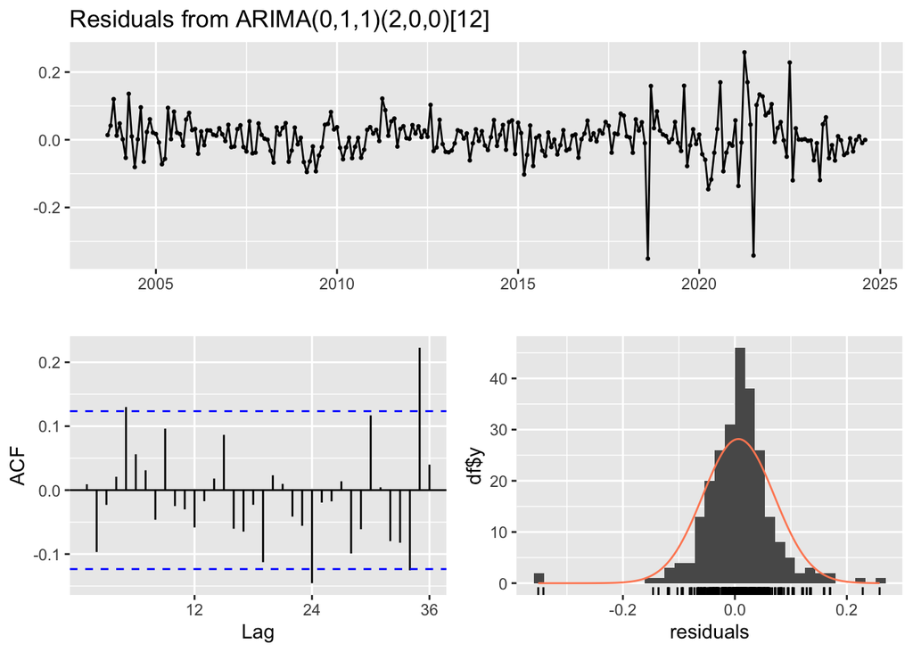

```
##
##  Ljung-Box test
##
## data:  Residuals from ARIMA(0,1,1)(2,0,0)[12]
## Q* = 27.84, df = 21, p-value = 0.1447
##
## Model df: 3.   Total lags used: 24
```

```r
checkresiduals(arima_fit)
```

## 4. Forecast 6 months ahead from training models

```r
f_ets <- forecast(ets_fit, h = 6)
f_arima <- forecast(arima_fit, h = 6)
arima_forecast_ts <- ts(f_arima$mean, start = c(2024, 9), frequency = 12)

acc_ets <- accuracy(f_ets, test)
acc_arima <- accuracy(f_arima, test)

print(acc_ets)
```

```
##                        ME       RMSE        MAE          MPE      MAPE
## Training set 0.0001428483 0.05753977 0.03652514 5.758389e-05 0.2492362
## Test set     0.0051893710 0.02707150 0.02235645 3.405422e-02 0.1475638
##                   MASE        ACF1 Theil's U
## Training set 0.4719118 -0.05043289        NA
## Test set     0.2888496  0.10603174 0.3003932
```

```r
print(acc_arima)
```

```
##                       ME       RMSE        MAE        MPE      MAPE      MASE
## Training set 0.006394385 0.06420888 0.04343998 0.04276191 0.2971094 0.5612529
## Test set     0.023767672 0.03367141 0.02652593 0.15619060 0.1744539 0.3427201
##                      ACF1 Theil's U
## Training set  0.009148398        NA
## Test set     -0.537733326 0.5102777
```

## 5. ts for plotting

```r
time_train <- time(train)
time_holdout <- time(test)
time_forecast <- time(f_ets$mean)
```

## 6. df for plotting

```r
df_train <- data.frame(Date = as.yearmon(time_train), Value = as.numeric(train), Type = "Training Data")
df_holdout <- data.frame(Date = as.yearmon(time_holdout), Value = as.numeric(test), Type = "Actual Holdout")
df_ets <- data.frame(Date = as.yearmon(time_forecast), Value = as.numeric(f_ets$mean), Type = "ETS Forecast")
df_arima <- data.frame(Date = as.yearmon(time_forecast), Value = as.numeric(f_arima$mean), Type = "ARIMA Forecast")
```

## 7. Combine

```r
full_df <- rbind(df_train, df_holdout, df_ets, df_arima)
```

## 8. Plot

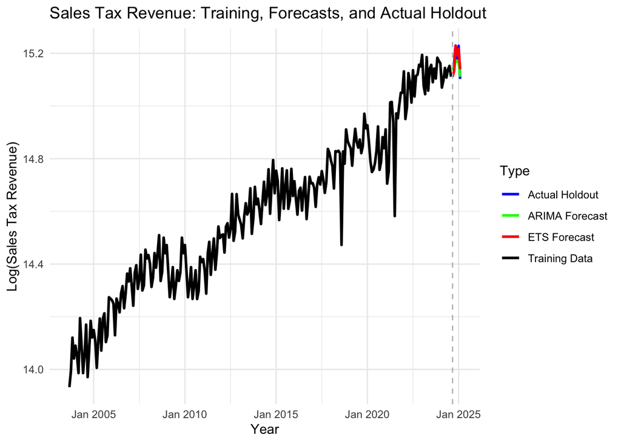

```r
ggplot(full_df, aes(x = Date, y = Value, color = Type)) +
  geom_line(size = 1) +
  geom_vline(xintercept = as.yearmon("2024-09"), linetype = "dashed", color = "grey") +
  ggtitle("Sales Tax Revenue: Training, Forecasts, and Actual Holdout") +
  xlab("Year") +
  ylab("Log(Sales Tax Revenue)") +
  scale_color_manual(values = c("Training Data" = "black", "Actual Holdout" = "blue",
                                "ETS Forecast" = "red", "ARIMA Forecast" = "green")) +
  theme_minimal()
```

## 9. Preferred model

```r
preferred_model <- if (acc_ets["Test set", "RMSE"] < acc_arima["Test set", "RMSE"]) "ETS" else "ARIMA"
print(paste("Preferred model:", preferred_model))
```

```
## [1] "Preferred model: ETS"
```

## 10. Forecast 30 months ahead

```r
if (preferred_model == "ETS") {
  final_model <- ets(log_sales_adj)
} else {
  final_model <- auto.arima(log_sales_adj, seasonal = TRUE, stepwise = FALSE)
}

forecast_30mo <- forecast(final_model, h = 30)
```

## 11. df for long forecast

```r
time_full <- time(log_sales_adj)
time_forecast_30 <- time(forecast_30mo$mean)

df_full <- data.frame(Date = as.yearmon(time_full), Value = as.numeric(log_sales_adj), Type = "Historical")
df_forecast <- data.frame(Date = as.yearmon(time_forecast_30), Value = as.numeric(forecast_30mo$mean), Type = "Forecast")

path_df <- rbind(df_full, df_forecast)
```

## 12. Plot

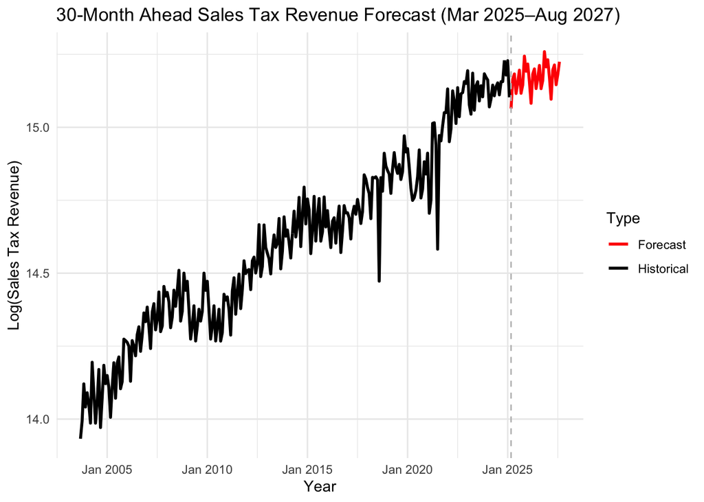

```r
ggplot(path_df, aes(x = Date, y = Value, color = Type)) +
  geom_line(size = 1) +
  geom_vline(xintercept = as.yearmon("2025-03"), linetype = "dashed", color = "grey") +
  ggtitle("30-Month Ahead Sales Tax Revenue Forecast (Mar 2025–Aug 2027)") +
  xlab("Year") +
  ylab("Log(Sales Tax Revenue)") +
  scale_color_manual(values = c("Historical" = "black", "Forecast" = "red")) +
  theme_minimal()
```

## 13. Back-transform forecast

```r
forecast_30mo_levels <- exp(forecast_30mo$mean)
```

## 14.Back-transform upper and lower prediction

```r
forecast_30mo_upper <- exp(forecast_30mo$upper[,2])
forecast_30mo_lower <- exp(forecast_30mo$lower[,2])
```

# PART C - JINRUI LI

## 1. Select 3 Variables

```r
dataset <- readxl::read_excel("~/Documents/课程文件/3. 674-Economic Forecasting/Term Project/Part C /PartC dataset.xlsx")
vehicletax_ts <- ts(dataset$`Motor Vehicle Sales and Rental Taxes`, frequency = 12, start = c(2003, 9))
retail_ts <- ts(dataset$`Retail Trade and Food Services(RSAFS)`, frequency = 12, start = c(2003, 9))
txur_ts <- ts(dataset$`Unemployment Rate in Texas(TXUR)`, frequency = 12, start = c(2003, 9))
```

### 3.b Answer: Variables Chosen

- Motor Vehicle Sales and Rental Taxes (State level): vehicle-related consumption is a significant part of taxable sales.
- Retail Sales (National level): reflects consumer spending.
- Texas Unemployment Rate (TXUR) (State level): macroeconomic indicator for consumer income.

## 2. Log-Transformation

```r
log_vehicletax_ts <- log(vehicletax_ts)
log_retail_ts <- log(retail_ts)
log_txur_ts <- log(txur_ts)
```

## 3. Stationarity Test

```r
ndiffs(log_sales_adj)
```

```
## [1] 1
```

```r
ndiffs(log_vehicletax_ts)
```

```
## [1] 1
```

```r
ndiffs(log_retail_ts)
```

```
## [1] 1
```

```r
ndiffs(log_txur_ts)
```

```
## [1] 1
```

### Analysis: All three time series need to be differenced once to achieve stationarity.

### 3.b Answer: Before modeling, all series were reprocessed for stationarity.

-a) Log transformations were applied to stabilize the variance. -b) The `ndiffs()` function were used to assess unit roots. -c) Each series was required first-order differencing to achieve stationarity before inclusion in the VAR model.

## 4. First-Order Differencing

```r
diff_sales_adj <- diff(log_sales_adj)
diff_vehicletax_ts <- diff(log_vehicletax_ts)
diff_retail_ts <- diff(log_retail_ts)
diff_txur_ts <- diff(log_txur_ts)
```

## 5. Dividing Training and Test Sets

```r
combined_ts <- cbind(diff_sales_adj, diff_vehicletax_ts, diff_retail_ts, diff_txur_ts)
colnames(combined_ts) <- c("sales", "vehicle", "retail", "TXUR")

training_set <- window(combined_ts, end = c(2024, 8))
test_set <- window(combined_ts, start = c(2024, 9))
```

## 6. VAR Modeling

```r
library(vars)
var_selection <- VARselect(training_set, lag.max = 12, type = "const")
var_selection$selection
```

```
## AIC(n)  HQ(n)  SC(n) FPE(n)
##     11     11      2     11
```

```r
var_model <- VAR(training_set, p = 2, type = "const")
summary(var_model)
```

```
##
## VAR Estimation Results:
## =========================
## Endogenous variables: sales, vehicle, retail, TXUR
## Deterministic variables: const
## Sample size: 249
## Log Likelihood: 1266.985
## Roots of the characteristic polynomial:
## 0.703 0.703 0.5526 0.5526 0.4409 0.4409 0.2963 0.06014
## Call:
## VAR(y = training_set, p = 2, type = "const")
##
##
## Estimation results for equation sales:
## ======================================
## sales = sales.l1 + vehicle.l1 + retail.l1 + TXUR.l1 + sales.l2 + vehicle.l2 + retail.l2 + TXUR.l2 + const
##
##             Estimate Std. Error t value Pr(>|t|)
## sales.l1   -0.561637   0.056216  -9.991  < 2e-16 ***
## vehicle.l1 -0.018715   0.016809  -1.113    0.267
## retail.l1   0.236240   0.393354   0.601    0.549
## TXUR.l1    -0.080549   0.118103  -0.682    0.496
## sales.l2   -0.484895   0.056024  -8.655 7.25e-16 ***
## vehicle.l2 -0.010190   0.016813  -0.606    0.545
## retail.l2   0.385500   0.324075   1.190    0.235
## TXUR.l2     0.032205   0.111217   0.290    0.772
## const       0.006843   0.005169   1.324    0.187
## ---
## Signif. codes:  0 '***' 0.001 '**' 0.01 '*' 0.05 '.' 0.1 ' ' 1
##
##
## Residual standard error: 0.0776 on 240 degrees of freedom
## Multiple R-Squared: 0.3525,  Adjusted R-squared: 0.3309
## F-statistic: 16.33 on 8 and 240 DF,  p-value: < 2.2e-16
##
##
## Estimation results for equation vehicle:
## ========================================
## vehicle = sales.l1 + vehicle.l1 + retail.l1 + TXUR.l1 + sales.l2 + vehicle.l2 + retail.l2 + TXUR.l2 + const
##
```

[output cut: 64 more lines]

```
##
##
## Covariance matrix of residuals:
##              sales    vehicle     retail       TXUR
## sales    0.0060215  0.0005096  0.0001773 -0.0004667
## vehicle  0.0005096  0.1394641  0.0009071 -0.0033655
## retail   0.0001773  0.0009071  0.0003713 -0.0009611
## TXUR    -0.0004667 -0.0033655 -0.0009611  0.0042073
##
## Correlation matrix of residuals:
##            sales  vehicle  retail     TXUR
## sales    1.00000  0.01758  0.1186 -0.09273
## vehicle  0.01758  1.00000  0.1260 -0.13894
## retail   0.11857  0.12604  1.0000 -0.76891
## TXUR    -0.09273 -0.13894 -0.7689  1.00000
```

### Note: Based on the VARselect() results, we opt for the lag order suggested by SC(BIC), which recommends 2 lags.

## 7. Using Test Set to Validate Model

```r
predict_model <- predict(var_model, n.ahead = 6)
predict_sales <- predict_model$fcst$sales[, "fcst"]

library(dplyr)
last_real_log_sales <- last(training_set[, "sales"])
predicted_log_sales6 <- cumsum(predict_sales) + last_real_log_sales
true_log_sales_test <- cumsum(test_set[, "sales"]) + last_real_log_sales

errors <- predicted_log_sales6 - true_log_sales_test
rmse <- sqrt(mean(errors^2))
mae <- mean(abs(errors))

cat("Validation RMSE:", rmse, "\n")
```

```
## Validation RMSE: 0.05389834
```

```r
cat("Validation MAE:", mae, "\n")
```

```
## Validation MAE: 0.04821945
```

## 8. Using Full Data to Forecast 30 Months

```r
full_training_set <- rbind(training_set, test_set)
full_var_model <- VAR(full_training_set, p = 2, type = "const")

predict_model_30m <- predict(full_var_model, n.ahead = 30)
sales_dlog_fcst_30m <- predict_model_30m$fcst$sales[, "fcst"]

last_real_log_sales_full <- last(full_training_set[, "sales"])
predict_log_sales_30m <- cumsum(sales_dlog_fcst_30m) + last_real_log_sales_full
predict_sales_tax_30m <- exp(predict_log_sales_30m)

dates_30m <- seq(as.Date("2025-03-01"), by = "month", length.out = 30)

predict_df <- data.frame(Date = dates_30m, Predicted_Sales_Tax = predict_sales_tax_30m)
head(predict_df)
```

```
##         Date Predicted_Sales_Tax
## 1 2025-03-01           0.9266254
## 2 2025-04-01           0.9647836
## 3 2025-05-01           0.9279105
## 4 2025-06-01           0.9386454
## 5 2025-07-01           0.9595617
## 6 2025-08-01           0.9508439
```

```r
write.csv(predict_df, file = "multivariate_sales_forecast_30m.csv", row.names = FALSE)
```

## 9. Plot 30-Month Forecast

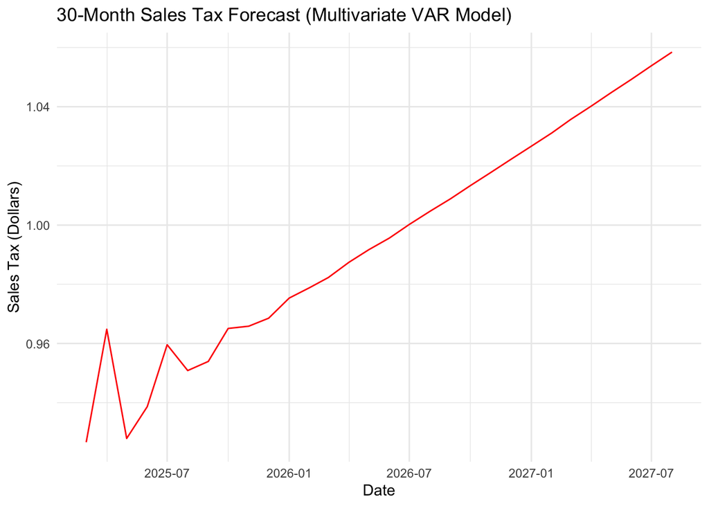

```r
ggplot(predict_df, aes(x = Date, y = Predicted_Sales_Tax)) +
  geom_line(color = "red") +
  labs(title = "30-Month Sales Tax Forecast (Multivariate VAR Model)",
       x = "Date", y = "Sales Tax (Dollars)") +
  theme_minimal()
```

# PART D - KRITI MATHUR

## Compare Forecasts

```r
# STEP 1: Read in the forecast files
ets <- read_csv("~/Desktop/univariate_sales_forecast_30m fromJoy.csv")
var <- read_csv("~/Desktop/multivariate_sales_forecast_30m（from Jinrui).csv")

# STEP 2: Convert to date format
ets$Date <- as.Date(ets$Date)
var$Date <- as.Date(var$Date)

# STEP 3: Assign fiscal years
ets$Fiscal_Year <- ifelse(month(ets$Date) >= 9, year(ets$Date) + 1, year(ets$Date))
var$Fiscal_Year <- ifelse(month(var$Date) >= 9, year(var$Date) + 1, year(var$Date))

# STEP 4: Summarize by fiscal year
ets_fy <- ets %>%
  group_by(Fiscal_Year) %>%
  summarise(ETS_Forecast = sum(Forecast))

var_fy <- var %>%
  group_by(Fiscal_Year) %>%
  summarise(VAR_Forecast = sum(Predicted_Sales_Tax))

# STEP 5: Add Comptroller's forecast
comptroller <- data.frame(
  Fiscal_Year = c(2025, 2026, 2027),
  Official = c(43977083, 46211370, 48026569)  # in thousands
)

# STEP 6: Join and compare
comparison <- ets_fy %>%
  inner_join(var_fy, by = "Fiscal_Year") %>%
  inner_join(comptroller, by = "Fiscal_Year") %>%
  mutate(
    ETS_Error = abs(ETS_Forecast - Official) / Official * 100,
    VAR_Error = abs(VAR_Forecast - Official) / Official * 100,
    Closer_Model = ifelse(ETS_Error < VAR_Error, "ETS", "VAR")
  )

# STEP 7: Show results
print(comparison)
```

```
## # A tibble: 3 × 7
##   Fiscal_Year ETS_Forecast VAR_Forecast Official ETS_Error VAR_Error
##         <dbl>        <dbl>        <dbl>    <dbl>     <dbl>     <dbl>
## 1        2025    22717081.    23283217. 43977083    48.3       47.1
## 2        2026    46575223.    48343808. 46211370     0.787      4.61
## 3        2027    47242742.    50942319. 48026569     1.63       6.07
## # ℹ 1 more variable: Closer_Model <chr>
```

### Comparative Analysis：

- Based on the forecast comparison with official Texas Comptroller projections, the ETS model was more accurate for FY 2026 and FY 2027, with lower percent errors of 0.79% and 1.63% respectively.
- In contrast, the VAR model performed slightly better in FY 2025, though both models deviated significantly that year. Overall, the ETS model produced more consistent and reliable forecasts, particularly in the medium term.